# Zhou analysis

Zaki Wilmot

14/03/2024

# Set-up

Load required library

```r
library(ggplot2)
library(dplyr)
library(reshape2)
library(ggbeeswarm)
library(gghighlight)
library(paletteer)
library(ggsignif)


library(DropletUtils)
library(scater)
library(Seurat)
library(Matrix)
library(UCell)
library(scran)
library(limma)
library(edgeR)
```

Specify the workspace

```r
workDir <- getwd()
workDir <- gsub("/scripts", "", workDir)
dataDir <- file.path(workDir, "data")
outDir <- file.path(workDir, "output")
dir.create(outDir)
set.seed(100)
```

> Knitr was reurning error when ‘file.path()’ was used. So we had to use full path to read in files. Please edit accordingly

Some colour scheme

```r
pal.tmp <- paletteer::paletteer_d("ggthemes::Tableau_20", 20)
pal.tmp2 <- c("#8CD17DFF",
              "#D4A6C8FF", pal.tmp[11], pal.tmp[12],
              pal.tmp[1], pal.tmp[2],
              "#9D7660FF")
```

Small function

```r
# Capitilisation of first letter
simpleCap <- function(x) {
  x <- tolower(x)
  s <- strsplit(x, " ")[[1]]
  paste(toupper(substring(s, 1,1)), substring(s, 2),
        sep="", collapse=" ")
}

# -------- Calculating dropout ------ #
dropOut_Pop <- function(se, POP){
  se_sub <- se[, se$Population %in% POP]

  gene_qc <- scater::perFeatureQCMetrics(se_sub)

  drp <- gene_qc$detected

  return(drp)
}
```

# Pre-processing

We prepare reference genome, download sequencing files and perform mapping

## Reference genome

We use the 10x reference genome. Reference genome can be downloaded from the download link provided at https://support.10xgenomics.com/single-cell-gene-expression/software/downloads/latest.

```bash
# 10x reference and GTF can be downloaded using wget
wget https://cf.10xgenomics.com/supp/cell-exp/refdata-gex-mm10-2020-A.tar.gz
```

## STAR preparation

We used STAR version: 2.7.9a. Using the STAR solo command

STAR index was generated as follows.

```bash
ml apps/star/2.7.9a

# Based on the guide https://github.com/alexdobin/STAR/blob/master/docs/STARsolo.md#multi-gene-reads
# To make the agreement between STARsolo and CellRanger even more perfect, you can add
# --genomeSAsparseD 3


STAR \
--runMode genomeGenerate \
--genomeDir ${outIndex} \
--genomeFastaFiles ${faFile} \
--sjdbGTFfile ${gtfFile} \
--genomeSAsparseD 3 \
--runThreadN 5
```

STAR mapping was done as follows

```bash
STAR \
--runThreadN 6 \
--soloType SmartSeq \
--readFilesCommand zcat \
--genomeDir <STAR_inde_location> \
--readFilesManifest <manifest_file_location> \
--outSAMattrRGline <manifest_file_location> \
--soloUMIdedup Exact \
--soloStrand Unstranded \
--soloFeatures Gene GeneFull \
--soloMultiMappers EM \
--genomeLoad NoSharedMemory \
--outSAMtype BAM SortedByCoordinate
```

## SRA download

The original publication of this paper is from https://www.nature.com/articles/nature17997. However we downloaded this data from SRA

```r
outDir_Zhou <- file.path(outDir, "Zhou_2016")
dir.create(outDir_Zhou)
```

There was no processed data provided, so we download the data from GEO

```bash
# 1) Donaload the list of SRA files
# 2) Use the sratoolkit module in cluster to download the SRA files
#  A table of files we want to download is in the data folder
prefetch --option-file SraAccList.txt

# Once data is downloaded by prefetch, we need to process using fasstq-dump convert SRA file to fasta file
fastq-dump --split-e  SRR1922583.sra

# Then we map the data with STAR solo, as we have done with the Next-seq and Smart-Seq2 data
# To map with star solo, we need to supply the manifest file ls -1 $PWD/* > ../tmp.list.txt
```

# Generate single cell object

Generate the single cell object

```r
# zhou.sce <- DropletUtils::read10xCounts(file.path(dataDir, "STAR_solo_output/Zhou_STARsolo/filtered"))

# Knitr gave error when reading, so we just load the saved data directly with full path
load("~/Desktop/Nat_comms_Ikba/data/zhou.sce.Rdata")
se <- zhou.sce
```

To annotate the genes further, we import the GTF file

```r
#simple_gtf <- read.delim(file.path(dataDir, "simple_gtf.txt"))
# Error with knitr again
simple_gtf <- read.delim("~/Desktop/Nat_comms_Ikba/data/simple_gtf.txt")

# Combine GTF with sc object
simple_gtf_sub <- simple_gtf %>%
  select(gene_id, gene_type, seqnames)
rD <- rowData(se) %>%
  as.data.frame() %>%
  left_join(simple_gtf_sub, by = c("ID" = "gene_id"))
```

Add cell metaData

```r
# Read the file accompanying the SRA file
mData_SRA <- read.csv("~/Desktop/Nat_comms_Ikba/data//GEO_download/Zhou_2016/SraRunTable_Zhou2016.csv")
# Read the manifest file used as input to STAR solo
mData_starSolo <- read.delim("~/Desktop/Nat_comms_Ikba/data/GEO_download/Zhou_2016/manifest_Zhou.txt",header=FALSE)

# We need to link the SRA name with the population identifier (eg T1 pre-HSC, T2 pre-HSC) with the name of the cells as named by STARsolo during mapping
mData_1<- mData_SRA %>%
  dplyr::select(Run, cell_type)
mData_2 <- mData_starSolo %>%
  mutate(Run = gsub("_1.fastq", "", V1),
         Run = gsub(".*fastq/", "", Run)) %>%
  dplyr::rename(Barcode = V3) %>%
  dplyr::select(Run, Barcode)
mData_comb <- left_join(mData_1, mData_2)
# Combine with cell annotation
cD <- colData(se) %>%
  as.data.frame() %>%
  left_join(mData_comb, by = c("Barcode" = "Barcode")) %>%
  dplyr::select(-Sample) %>%
  dplyr::rename(condition = cell_type)
```

Rename the populations in the Zhou data

```r
table(cD$condition)
```

```
##
##                                      E12 HSCs
##                                            21
##                                      E14 HSCs
##                                            32
##                             endothelial cells
##                                            17
##                     Haematopoietic stem cells
##                                            46
## T1 CD201-: CD31+CD45-CD41low c-Kit+CD201low/-
##                                            42
##                                   T2 pre-HSCs
##                                            44
##                                Type1 pre-HSCs
##                                            28
##                                Type2 pre-HSCs
##                                            32
```

New names

```r
# Make a factor level
Zhou_lvl <- c("AGM_E11.0_Endo", "AGM_E11.0_T1_preHSC_CD201neg", "AGM_E11.0_T1_preHSC_CD201hig",
              "AGM_E11.0_T2_preHSC_CD201hig", "AGM_E11.0_T2_preHSC",
              "FL_E12.0_HSC", "FL_E14.0_HSC",
              "BM_Adult_HSC")

# Rename
NewName <- cD$condition
NewName <- dplyr::case_when(
  NewName == 'endothelial cells' ~ "AGM_E11.0_Endo",
  NewName == 'T1 CD201-: CD31+CD45-CD41low c-Kit+CD201low/-' ~ "AGM_E11.0_T1_preHSC_CD201neg",
  NewName == 'Type1 pre-HSCs' ~ "AGM_E11.0_T1_preHSC_CD201hig",

  NewName == 'T2 pre-HSCs' ~ "AGM_E11.0_T2_preHSC_CD201hig",
  NewName == 'Type2 pre-HSCs' ~ "AGM_E11.0_T2_preHSC",

  NewName == 'E12 HSCs' ~ "FL_E12.0_HSC",
  NewName == 'E14 HSCs' ~ "FL_E14.0_HSC",
  NewName == 'Haematopoietic stem cells' ~ "BM_Adult_HSC",

)
NewName <- factor(NewName, levels=Zhou_lvl)

cD$condition <- NewName
```

Add new colData and rowData to se object

```r
colData(se) <- DataFrame(cD)
rowData(se) <- DataFrame(rD)
```

## Filtering low-quality cells

Our first aim is to remove low-quality cells. For all of the run, we apply a threshold to filter the cells. We will use the follwoing

- Number of genes detected
- Percentage of Mitochondira reads
- Percentage of Hemoglobin (Hbb) genes

Find the QC of specific genes

```r
# Specific the location
MT_gene <- rD$seqnames == "chrM"
Hbbs <- rD[grepl("Hb[a-b]", rD$Symbol),] %>% pull(Symbol)
Hbbs <- c(Hbbs, "Gypa")
#Hbbs <- c("Hba-x", "Hbb-bh1", "Hbb-y", "Hba-a1")

# Get the Ens ID
Hb_ens <- rD %>%
  dplyr::filter(Symbol %in% Hbbs)
Hbb_gene <- rowData(se)$ID %in% Hb_ens$ID
```

We examine the distibution of the data in all the run

```r
df_cData <-
  perCellQCMetrics(se,
                   subsets=list(Mito=MT_gene,
                                Hbb=Hbb_gene)) %>%
  cbind(as.data.frame(colData(se))) %>%
  as.data.frame() %>%
  dplyr::mutate(Cell = colnames(se))


# To plot select a subset of columns
df_cData_sub <- as.data.frame(df_cData) %>%
  #tibble::rownames_to_column(var = "Cell") %>%
  dplyr::select(Barcode, sum, detected, subsets_Mito_percent, subsets_Hbb_percent, condition)



m <- melt(df_cData_sub)
```

Plot the distribution

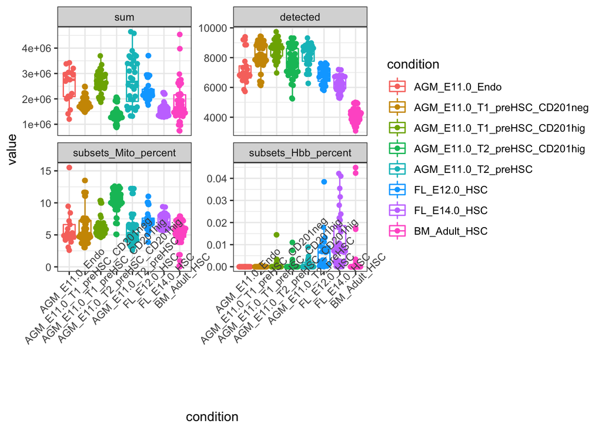

```r
ggplot(m, aes(x=condition, y=value, colour=condition)) +
  geom_boxplot(aes(),fill=NA) +
  geom_quasirandom(dodge.width=0.75) +
  theme_bw()  +
  facet_wrap(~variable, scales = "free_y") +
  theme(axis.text.x = element_text(angle = 45)) +
  NULL
```

Lets apply a cut-off

```r
df_cData_fil <- df_cData_sub %>%
  dplyr::filter(
    detected > 2000,
    subsets_Mito_percent < 15,
    subsets_Hbb_percent < 10)
```

Subset the sc object

```r
se <- se[,se$Barcode %in% df_cData_fil$Barcode]
```

## Convert to gene symbol

To enable a user-friendly analysis, it is convenient to exchange the ENSEMBL IDs with the name of the genes.

For duplicated gene names, we merge them with the ENSEMBL IDs to avoid confusion.

```r
new.row.names <- uniquifyFeatureNames(
    rowData(se)$ID,
    rowData(se)$Symbol
)

rownames(se) <- new.row.names
head(rownames(se), 5)
```

```
## [1] "Xkr4"    "Gm1992"  "Gm19938" "Gm37381" "Rp1"
```

```r
se_Zhou <- se
```

# Quick seurat

```r
colnames(se) <- se$Barcode
seu <-
  Seurat::CreateSeuratObject(counts = assay(se, "counts"),
                     project = "Zhou",
                     meta.data = as.data.frame(colData(se)),
                     min.cells = 3, min.features = 200)
# Colour scheme
#pal.pop2_sub <- df_pal_pop2 %>%
#  dplyr::filter(Population %in% se2$condition) %>% pull(Col)


seuset <- NormalizeData(
  object = seu,
  normalization.method = "LogNormalize",
  scale.factor = 10000
)
# Feature selections
seuset <-
  FindVariableFeatures(object = seuset, selection.method = "vst", nfeatures = 2500)
# Scaling the data
all.genes <- rownames(x = seuset)
seuset <- ScaleData(object = seuset, features = all.genes)
```

```r
# These are now standard steps in the Seurat workflow for visualization and clustering
seuset <- RunPCA(seuset, verbose = FALSE)
#ElbowPlot(object = seuset, ndims = 30)
seuset <- RunUMAP(seuset, dims = 1:30, verbose = FALSE)
seuset <- FindNeighbors(seuset, dims = 1:30, verbose = FALSE)
seuset <- FindClusters(seuset, verbose = FALSE,resolution = 1)

seuset_zhou <- seuset
```

## UMAP visualisation

Extract the UMAP dimension

```r
umap.df <- as.data.frame(Embeddings(object = seuset, reduction = "umap")) %>%
  tibble::rownames_to_column(var="Cell") %>%
  cbind(seuset[[]])


# Subset based on sorted population
p1 <-
  ggplot(umap.df, aes(x=UMAP_1, y=UMAP_2, colour=condition)) +
  geom_point() +
  gghighlight(use_direct_label = FALSE) +
  theme(legend.position = "right") +
  facet_wrap(~condition) +
  theme_bw() +
  #scale_colour_manual(values=pal.pop2_sub) +
  labs(title="Highlighting the FACS population")

p2 <-
  ggplot(umap.df, aes(x=UMAP_1, y=UMAP_2, colour=seurat_clusters)) +
  geom_point() +
  gghighlight(use_direct_label = FALSE) +
  theme(legend.position = "right") +
  facet_wrap(~seurat_clusters) +
  theme_bw() +
  #scale_colour_manual(values=pal.pop2_sub) +
  labs(title="Highlighting the in silico clusters")

png(file.path(outDir, "Zhou_UMAP_condition.png"), width=1200, height=900)
p1
dev.off()
```

```r
png(file.path(outDir, "Zhou_UMAP_cluster.png"), width=1200, height=900)
p2
dev.off()
```

```r
su.markers <-
  FindAllMarkers(seuset, only.pos = TRUE, min.pct = 0.25, logfc.threshold = 0.25)
write.csv(su.markers, file.path(outDir, "MarkerGenes.csv"))
```

## Filtering clusters

Cluster 5 showed no expression of CD27 and very high expression of Macrophage (Fcr gene family) expression. So we remove all cluster 5

Show expression of Fcr

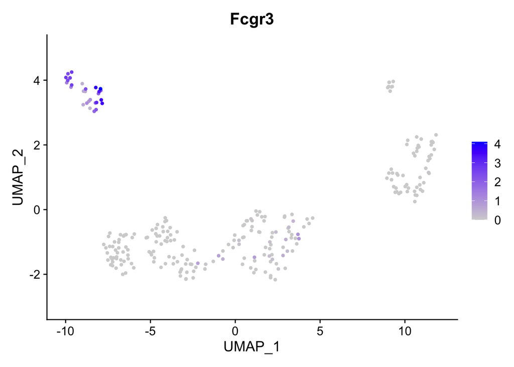

```r
FeaturePlot(seuset, reduction = "umap",
            features = c("Fcgr3"),order = T)
```

Remove cluster 5

```r
seuset <- seuset[,!seuset$seurat_clusters == "5"]
```

Re-run clustering and variable genes

```r
# Feature selections
seuset <-
  FindVariableFeatures(object = seuset, selection.method = "vst", nfeatures = 2500)
# Scaling the data
all.genes <- rownames(x = seuset)
seuset <- ScaleData(object = seuset, features = all.genes)
```

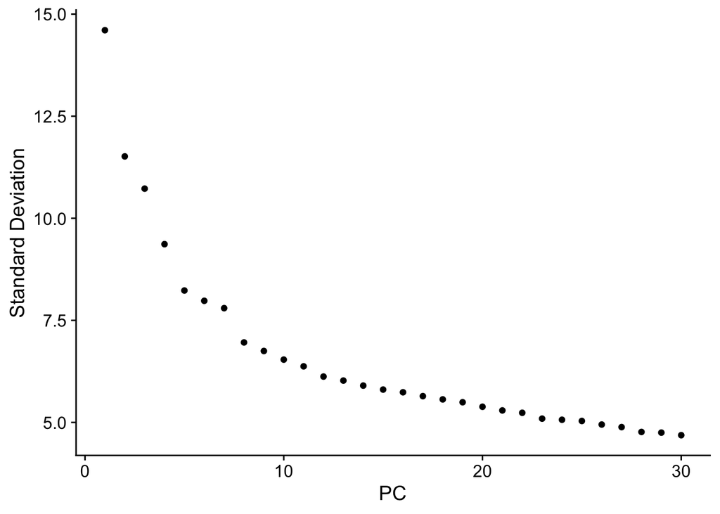

```r
# These are now standard steps in the Seurat workflow for visualization and clustering
seuset <- RunPCA(seuset, verbose = FALSE)
ElbowPlot(object = seuset, ndims = 30)
```

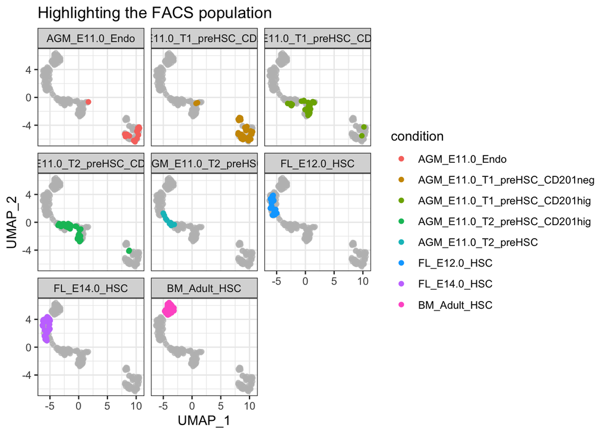

```r
seuset <- RunUMAP(seuset, dims = 1:30, verbose = FALSE)

seuset <- FindNeighbors(seuset, dims = 1:30, verbose = FALSE)
seuset <- FindClusters(seuset, verbose = FALSE,resolution = 1)

seuset_zhou <- seuset


umap.df <- as.data.frame(Embeddings(object = seuset, reduction = "umap")) %>%
  tibble::rownames_to_column(var="Cell") %>%
  cbind(seuset[[]])


# Subset based on sorted population
p1 <-
  ggplot(umap.df, aes(x=UMAP_1, y=UMAP_2, colour=condition)) +
  geom_point() +
  gghighlight(use_direct_label = FALSE) +
  theme(legend.position = "right") +
  facet_wrap(~condition) +
  theme_bw() +
  #scale_colour_manual(values=pal.pop2_sub) +
  labs(title="Highlighting the FACS population")

p1
```

# Interested populations

The population *AGM_E11.0_T1_preHSC_CD201neg* appears clustering with Endo. Hence we are not interested in this population. Re-analyze the data without this population.

```r
# Save original
seuset_zhou_ori <- seuset_zhou

seuset_zhou2 <- seuset_zhou[,!seuset_zhou$condition %in%
                             #c("AGM_E11.0_T1_preHSC_CD201neg","FL_E12.0_HSC", "FL_E14.0_HSC", "BM_Adult_HSC")]
                             c("AGM_E11.0_T1_preHSC_CD201neg")]



tmp <- seuset_zhou2$condition
tmp <- case_when(tmp == "AGM_E11.0_Endo" ~ "EC",
                 tmp == "AGM_E11.0_T1_preHSC_CD201hig" ~ "T1-preHSC",
                 tmp == "AGM_E11.0_T2_preHSC" ~ "T2-CD41_low",
                 tmp == "AGM_E11.0_T2_preHSC_CD201hig" ~ "T2-preHSC",
                 tmp == "FL_E12.0_HSC" ~ "FL_E12.0_HSC",
                 TRUE ~ as.character(tmp))
tmp <- factor(tmp, levels =
                        c("EC", "T1-preHSC",
                          "T2-CD41_low",
                          "T2-preHSC",
                          "FL_E12.0_HSC", "FL_E14.0_HSC",
                          "BM_Adult_HSC"))
seuset_zhou2$condition2 <- tmp

# Recompute UMAP
seuset <- seuset_zhou2
seuset <-
  FindVariableFeatures(object = seuset, selection.method = "vst", nfeatures = 2500)
# Scaling the data
all.genes <- rownames(x = seuset)
seuset <- ScaleData(object = seuset, features = all.genes)
```

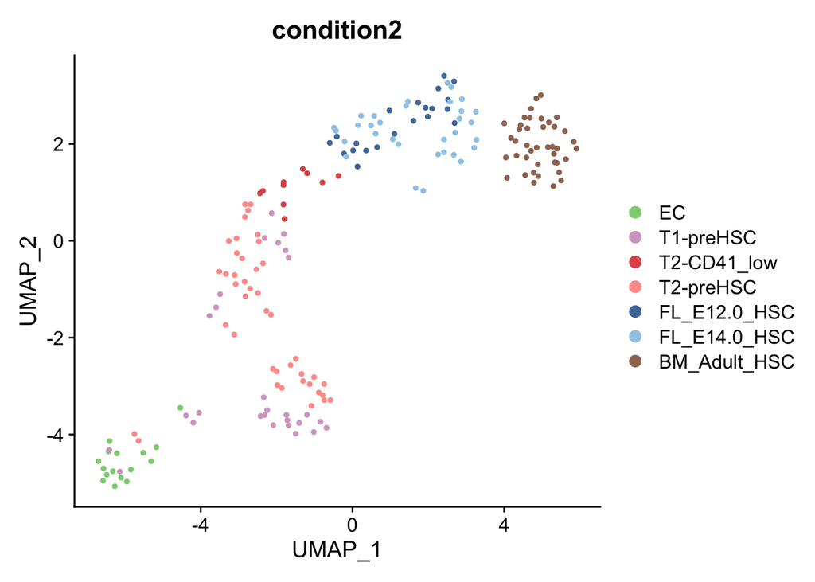

```r
#seuset <- CellCycleScoring(seuset, s.features = s.genes, g2m.features = g2m.genes, set.ident = FALSE)


# These are now standard steps in the Seurat workflow for visualization and clustering
seuset <- RunPCA(seuset, verbose = FALSE)
#ElbowPlot(object = seuset, ndims = 30)
seuset <- RunUMAP(seuset, dims = 1:30, verbose = FALSE, set.seed = 9999)
seuset <- FindNeighbors(seuset, dims = 1:30, verbose = FALSE)
seuset <- FindClusters(seuset, verbose = FALSE,resolution = 1)

pal.tmp2 <- c("#8CD17DFF",
              "#D4A6C8FF", pal.tmp[11], pal.tmp[12],
              pal.tmp[1], pal.tmp[2],
              "#9D7660FF")
DimPlot(seuset, reduction = "umap", group.by = "condition2", cols=pal.tmp2)
```

```r
ggsave(file.path(outDir, "Zhou_UMAP.pdf"), device = "pdf", width=8, height = 5, dpi=300)
```

Now plot some interested genes on the UMAP

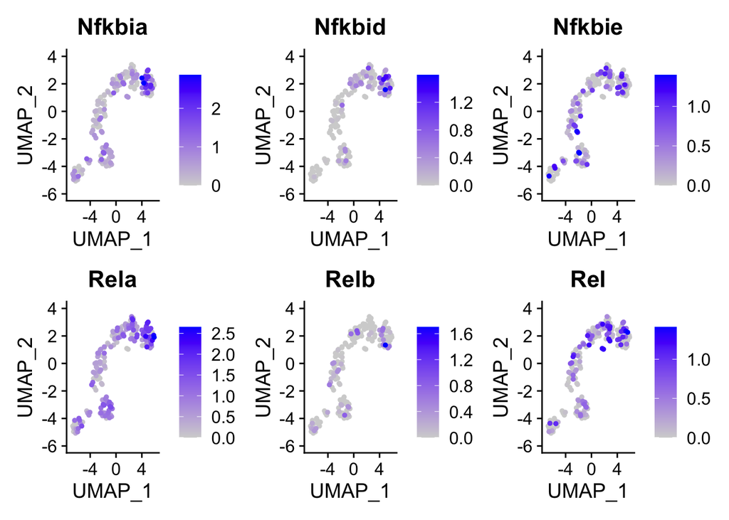

```r
FeaturePlot(seuset, reduction = "umap",
            features = c("Nfkbia", "Nfkbid", "Nfkbie",
                         "Rela", "Relb", "Rel"),
            ncol = 3,order = T)
```

# Signature score

Now we calculate the a signature score from mulitple genes.

First define the signatures

```r
# List of NfkB members that were manually curated
#list_1 <- read.csv(file.path(dataDir, "list_1_small_genes.csv")) %>% pull(genes)
list_1 <- read.csv("~/Desktop/Nat_comms_Ikba/data/list_1_small_genes.csv") %>% pull(genes)

# Selected Inflammation genes
#list_2 <- read.csv(file.path(dataDir, "list_2_Inflm.csv")) %>% pull(genes)
list_2 <- read.csv("~/Desktop/Nat_comms_Ikba/data/list_2_Inflm.csv") %>% pull(genes)

# Long GSEA gene list of TNFA extrated from Hallmark
#list_3 <- read.csv(file.path(dataDir, "list_3_GSEA.csv"))
list_3 <- read.csv("~/Desktop/Nat_comms_Ikba/data//list_3_GSEA.csv")
list_3 <- as.character(mapply(simpleCap, list_3$genes)) # Convert to lower case

# Convert as list
seu_lists <- list(list_1, list_2, list_3)
names(seu_lists) <- c("NFKB_curated", "Inflm", "Hallmark_NFKB")
```

Calculate the score using ‘Ucell’ package. Remove populations that we are not interested in

```r
seuset_zhou <- seuset_zhou[,!seuset_zhou$condition %in%
                             #c("AGM_E11.0_T1_preHSC_CD201neg","FL_E12.0_HSC", "FL_E14.0_HSC", "BM_Adult_HSC")]
                             c("AGM_E11.0_T1_preHSC_CD201neg", "AGM_E11.0_T2_preHSC")]

seuset_zhou <- AddModuleScore_UCell(seuset_zhou, features = seu_lists)
```

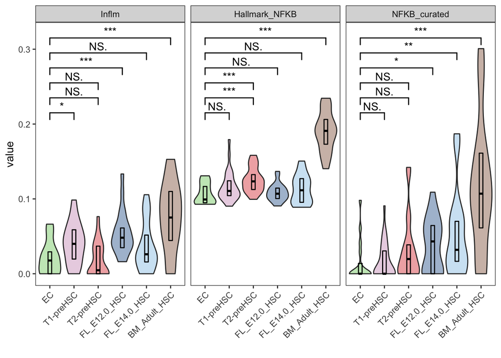

```r
df_plot2 <- data.frame(seuset_zhou[[]]) %>%
  dplyr::select(condition, NFKB_curated_UCell:Hallmark_NFKB_UCell) %>%
  dplyr::mutate(
    condition = case_when(condition == "AGM_E11.0_Endo" ~ "EC",
                          condition == "AGM_E11.0_T1_preHSC_CD201hig" ~ "T1-preHSC",
                          condition == "AGM_E11.0_T2_preHSC" ~ "T2-CD41_low",
                          condition == "AGM_E11.0_T2_preHSC_CD201hig" ~ "T2-preHSC",
                          condition == "FL_E12.0_HSC" ~ "FL_E12.0_HSC",
                          TRUE ~ as.character(condition))) %>%
  dplyr::mutate(
    condition = factor(condition, levels =
                        c("EC", "T1-preHSC",
                          "T2-CD41_low",
                          "T2-preHSC",
                          "FL_E12.0_HSC", "FL_E14.0_HSC",
                          "BM_Adult_HSC"))) %>%
  melt() %>%
  dplyr::mutate(variable = gsub("_UCell", "", variable),
                variable = factor(variable, levels=c("Inflm", "Hallmark_NFKB", "NFKB_curated")))
# Plot
pal.tmp3 <- c("#8CD17DFF",
              "#D4A6C8FF", pal.tmp[11], #pal.tmp[12],
              pal.tmp[1], pal.tmp[2],
              "#9D7660FF")


p_viol_gene2 <-
  df_plot2 %>%
  ggplot(aes(x = condition, y = value, fill = condition)) +
  geom_violin(alpha = 0.5, scale = "width", position = position_dodge(width = 0.9)) +
  geom_boxplot(aes(), coef=0,
               fill=NA, colour="black", outlier.alpha = 0,  width = 0.15, position = position_dodge(width = 0.9)) +
  scale_fill_manual(values=unique(pal.tmp3)) +
  theme_bw() +
  theme(legend.position = "none",
        panel.grid.major = element_line(linetype = "blank"),
        panel.grid.minor = element_line(linetype = "blank"),
        axis.text.x = element_text(angle = 45, hjust = 1)) +
  #scale_y_continuous(limits = c(0,12),
  #                   breaks = c(0,5,10)) +
  xlab("") +
  facet_wrap(~variable, ncol = 5) +
  geom_signif(comparisons = list(
    c("EC", "T1-preHSC"),
    c("EC", "T2-preHSC"),
    c("EC", "T2-preHSC"),
    c("EC", "FL_E12.0_HSC"),
    c("EC", "FL_E14.0_HSC"),
    c("EC", "BM_Adult_HSC")),
    map_signif_level=TRUE, test = "t.test",
    y_position = c(0.2,0.22,0.24,0.26,0.28,0.3)
    ) +
  scale_y_continuous(limits = c(0,0.32), breaks=c(0,0.1,0.2,0.3)) +
  NULL

p_viol_gene2
```

```r
ggsave(file.path(outDir, "Zhou_Signature2.pdf"), device = "pdf", width=12, height = 4, dpi=300)
```